# Old Faithful Geyser

The [Old Faithful Geyser](https://stat.ethz.ch/R-manual/R-devel/library/datasets/html/faithful.html) data set is a well-known data set that depicts the relationship of the waiting time between eruptions and the duration of the eruption for the Old Faithful geyser in Yellowstone National Park, Wyoming, USA [[webcam]](http://yellowstone.net/webcams/).

`faithful` is a data set with 272 observations on 2 variables.

| Column name | Description |
| --- | --- |
| eruptions | Duration time of previous eruption time (in mins) |
| waiting | Waiting time to next eruption (in mins) |

Let’s load the `faithful` dataset.

```r
data(faithful)
head(faithful)
```

```
##   eruptions waiting
## 1     3.600      79
## 2     1.800      54
## 3     3.333      74
## 4     2.283      62
## 5     4.533      85
## 6     2.883      55
```

This is a histogram of the time between eruptions. We see the are two groups of waiting times to the next eruption: One group with mean around 55 minutes and a second group with a mean around 80 minutes.

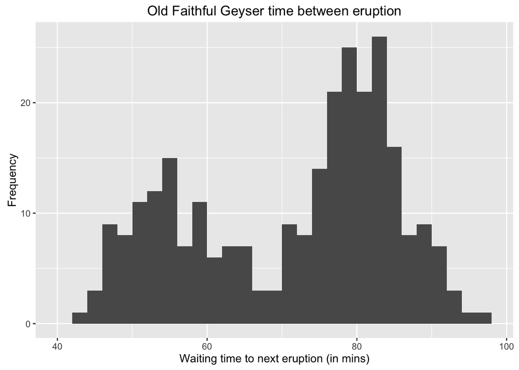

```r
library(ggplot2)
library(dplyr)

faithful %>%
    ggplot(aes(x = waiting)) + geom_histogram(binwidth = 2) +
    xlab("Waiting time to next eruption (in mins)") +
    ylab("Frequency") +
    labs(title="Old Faithful Geyser time between eruption")
```

This histogram indicates [Old Faithful isn’t as “faithful” as you might think](http://people.stern.nyu.edu/jsimonof/classes/2301/pdf/geystime.pdf).

Let’s look at the relationship between the duration of the previous eruption and how it related to the waiting time until the next eruption.

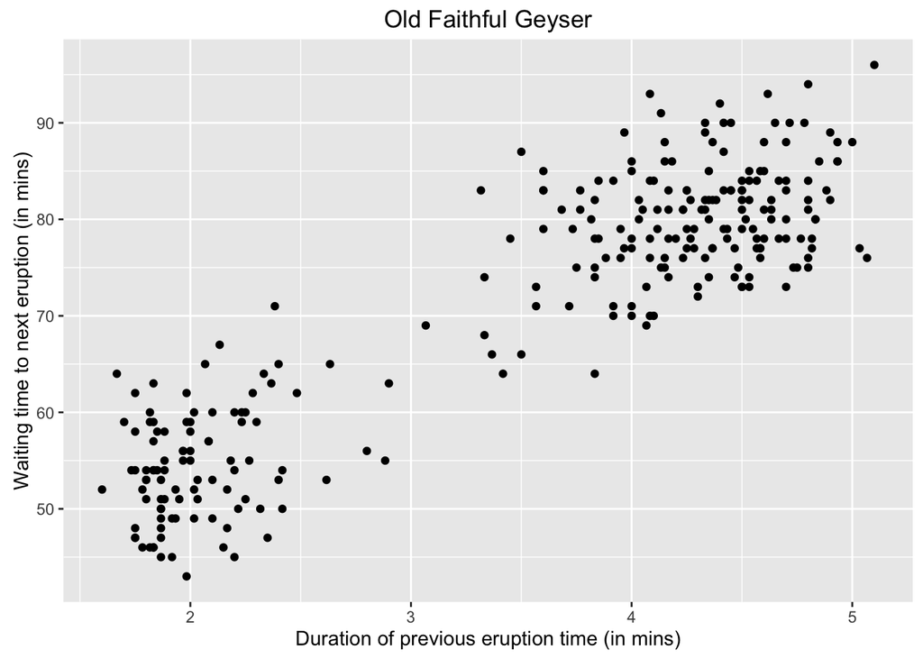

```r
faithful %>%
    ggplot(aes(x = eruptions, y = waiting)) + geom_point() +
    xlab("Duration of previous eruption time (in mins)") +
    ylab("Waiting time to next eruption (in mins)") +
    labs(title="Old Faithful Geyser")
```

We see that the relationship between these two variables is fairly linear, which suggests that we might use a linear model to predict the waiting time until the next eruption based on the duration of the previous eruption.